# Creating data ourselves

DSST 289: Introduction to Data Science

Erik Fredner

September 23, 2024

# Overview

- Exam follow-up
- DIY data
- 🎥 Movies data set

# Exam follow-up

- Goal is to complete grading by Monday the 30th
- We will review the answers for the take-home and in-class part once grades are out

## Survey

Please fill out the following survey to help me understand how you are feeling after the the exam. This will also help me plan what we need to review.

**Survey is anonymous!**

https://richmond.ca1.qualtrics.com/jfe/form/SV_8J8eGwk8zA7vz0y

(Also available as a link on Blackboard in the Course Documents folder for today.)

# DIY Data

- So far we have been using pre-made data
- Often, you need to create (or update) your own data
  - It’s possible to do this badly!
- We’ll practice some good habits

## Tidy data principles

- Rows contain observations
- Columns contain variables
  - Columns all have the same data type (character, numeric, etc.)
- Cells contains values
  - Each cell contains *only one* piece of information
- See the [“Data tidying”](https://r4ds.hadley.nz/data-tidy.html) chapter

## Making tables

- Each table should contain comparable observations
- When observing different things (even if they’re closely related), you probably need different tables
- Each table should begin from cell A1, have a header row, and be rectangular

## Explicitness

- Choices made in data collection should be explicit and documented
- Data dictionaries describe your choices and assumptions
- Leaving decisions implicit will harm your future self and your analyses

## Bad example: color for meaning

**Warning**

Using color to convey meaning is bad because it is **not** explicit

[figure not shown]

Example of why color for meaning is bad (`food_group`)

## Good example: explicitness and consistency with data validation

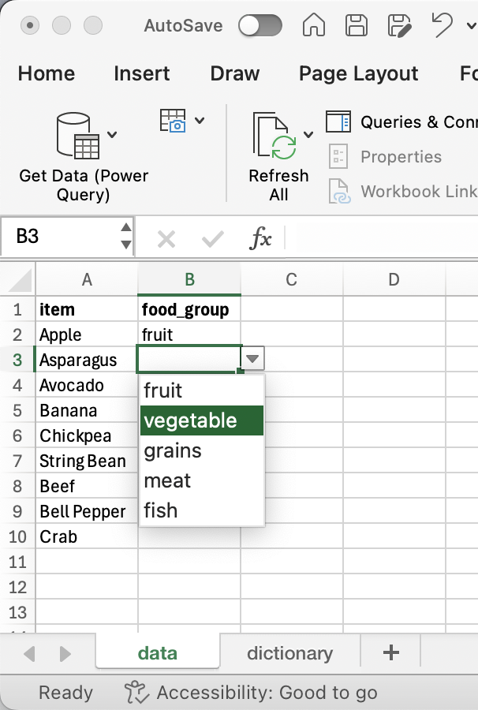

Example of data validation in Excel

## Practice: 🎥 Movies data

- We will create a data set about movies to practice
- The link is in the Blackboard folder for today and [here](https://docs.google.com/spreadsheets/d/189QVmv5_2raf_ii-49UKnud4n3ITPmRcKOdHZzNs0G8/edit?usp=sharing)

## Review

1. Tidy data
2. When to make tables
3. How to make tables (Microsoft Excel or Google Sheets)
4. Data dictionaries
5. Data validation
6. Conditional formatting
7. Exporting to `.csv` for preservation and analysis

[figure not shown]

https://fredner.org